# S2 new analysis (Improved)

2024-12-16

This is the second script for study 2 of the current project. The purpose of this script is analyzing the data generated by the `S2_gen_data_optimized.ipynb` script.

By analyzing these synthetic data, we generate concrete predictions for our theory.

We will show how the design parameters (P, T, W) affect the DDM parameters (a, v) and behavioral outcomes (RT, ACC), and how the self-prioritization effect (SPE) in these parameters varies across the design space. For each target variable (a, v, RT, ACC), we will plot the following:

1. **Raw data in 3D** - 3D scatter plots showing raw data points for self and stranger conditions separately (2 plots)
2. **Raw data in 2D** - 2D contour plots with GAM smoothing for self and stranger conditions (6 plots)
3. **Raw differences** - Self-stranger differences by P, T, and W (6 plots with summary statistics and sampled raw points: 3 with the difference on y-axis, 3 with the both self and stranger’s values on y-axis, make a two-row layout with the uppper raw for the self and strangers’ values, and the lower row for the differences)
4. **Standardized differences (Cohen’s d)** - 3D scatter plot of Cohen’s d
5. **Cohen’s d in 2D** - 3 contour plots (P&W, T&W, T&P) with GAM smoothing

That said, for each target variable’s raw data, we will have 8 plots in total (2 3D scatter + 6 2D GAM contours). For the self-stranger differences (SPE), we plot both raw differences and Cohen’s *d*. For raw differences, we plot 6 summary plots (3 showing self/stranger profiles, 3 showing differences). For Cohen’s *d*, we plot 1 3D scatter and 3 2D GAM contours. Thus, for each target variable, we will have 18 plots in total.

## Changelog (Major Improvements from S2_ana_fan.Rmd)

| # | Aspect | Before | After |
| --- | --- | --- | --- |
| 1 | Lines of code | 1297 | 713 (**45% reduction**) |
| 2 | Environment clear | No | Yes (`rm(list = ls())`) |
| 3 | Variable naming | P, T, W | P_val, T_val, W_val |
| 4 | Cohen’s *d* function | Inline code | `calc_cohens_d_vec()` from utils.R |
| 5 | Helper functions | Scattered in file | In utils.R |
| 6 | Organization | By function type | By target variable |
| 7 | Contour plots | plot_ly only | ggplot + patchwork + GAM |
| 8 | Plot layout | Individual | patchwork grids with shared legends |
| 9 | GAM smoothing | Multiple methods | Single recommended method |
| 10 | Data sparsity | Not shown | Explained in Section 3 |
| 11 | Documentation | Minimal | Table of contents added |

This is the code for new analysis of S2 data, including contour plot and 3D scatter plot.

- P_val: length of practices (P)
- T_val: presenting time (T)
- W_val: time window for response (W)

| # | Section | Target Variable(s) | Data Source |
| --- | --- | --- | --- |
| 1 | Setup | - | Load packages, data |
| 2 | Data Preprocessing | P_val, T_val, W_val | df, df_sum_cond, df_sum_cond_w |
| 3 | 2D Contour Methods | - | Methods comparison |
| 4 | Boundary Separation (a) | mean_a_self/stranger, a_diff, cohen_d_a | df_sum_cond_w |
| 5 | Drift Rate (v) | mean_v_self/stranger, v_diff, cohen_d_v | df_sum_cond_w |
| 6 | Reaction Time (RT) | mean_RT_self/stranger, RT_diff, cohen_d_RT | df_sum_cond_w |
| 7 | Accuracy (ACC) | mean_ACC_self/stranger, ACC_diff, cohen_d_ACC | df_sum_cond_w |

# 1. SETUP

# 2. DATA PREPROCESSING

```r
# Test mode toggle (set TRUE for faster iteration)
test <- TRUE

# Import raw data (match condition)
# response = 1 (correct), = 2 (error)
df <- bruceR::import(here::here("Study2", "data", "260220.csv")) %>%
  dplyr::mutate(RT = RT * 1000,
                correct = ifelse(response == 2, 0, 1)) %>%
  dplyr::rename(P_val = P, T_val = `T`, W_val = W)

if (isTRUE(test)) {
  set.seed(123)
  subject_ids <- unique(df$subjectID)
  sampled_ids <- sample(subject_ids, size = min(5000, length(subject_ids)))
  df <- dplyr::filter(df, subjectID %in% sampled_ids)
}
```

```r
## Condition-Level Summary
df_sum_cond <- df %>%
  group_by(subjectID, Label, P_val, T_val, W_val) %>%
  summarise(
    mean_RT = mean(RT),
    sd_RT = sd(RT),
    mean_ACC = mean(response == 1),
    sd_ACC = sd(response == 1),
    mean_a = mean(a),
    sd_a = sd(a),
    mean_v = mean(v),
    sd_v = sd(v),
    n = n(),
    .groups = "drop"
  )

# Pivot to wide format
df_sum_cond_w <- df_sum_cond %>%
  tidyr::pivot_wider(
    id_cols = c(subjectID, P_val, T_val, W_val),
    names_from = Label,
    values_from = c(mean_RT, sd_RT, mean_ACC, sd_ACC, mean_a, sd_a, mean_v, sd_v, n)
  )

# Calculate Cohen's d for RT, ACC, and DDM parameters (a, v)
df_sum_cond_w <- df_sum_cond_w %>%
  dplyr::mutate(
    # Raw differences (SPE)
    RT_diff = mean_RT_stranger - mean_RT_self,
    ACC_diff = mean_ACC_self - mean_ACC_stranger,
    a_diff = mean_a_self - mean_a_stranger,
    v_diff = mean_v_self - mean_v_stranger,
    # Cohen's d for RT (RT: stranger slower = positive d)
    cohen_d_RT = calc_cohens_d_vec(
      mean_self = mean_RT_self, mean_stranger = mean_RT_stranger,
      sd_self = sd_RT_self, sd_stranger = sd_RT_stranger,
      n_self = n_self, n_stranger = n_stranger,
      direction = "stranger_minus_self"
    ),
    # Cohen's d for ACC (ACC: self better = positive d)
    cohen_d_ACC = calc_cohens_d_vec(
      mean_self = mean_ACC_self, mean_stranger = mean_ACC_stranger,
      sd_self = sd_ACC_self, sd_stranger = sd_ACC_stranger,
      n_self = n_self, n_stranger = n_stranger,
      direction = "self_minus_stranger"
    ),
    # Cohen's d for boundary separation a (self > stranger = positive d)
    cohen_d_a = calc_cohens_d_vec(
      mean_self = mean_a_self, mean_stranger = mean_a_stranger,
      sd_self = sd_a_self, sd_stranger = sd_a_stranger,
      n_self = n_self, n_stranger = n_stranger,
      direction = "self_minus_stranger"
    ),
    # Cohen's d for drift rate v (self > stranger = positive d)
    cohen_d_v = calc_cohens_d_vec(
      mean_self = mean_v_self, mean_stranger = mean_v_stranger,
      sd_self = sd_v_self, sd_stranger = sd_v_stranger,
      n_self = n_self, n_stranger = n_stranger,
      direction = "self_minus_stranger"
    )
  )

# head(df_sum_cond_w)
rm(df) # to save the memory
```

```r
make_gam_grid <- function(data, response_col, grid_size = 30) {
  formula <- stats::as.formula(paste(response_col, "~ te(P_val, T_val, W_val)"))
  model <- mgcv::gam(formula, data = data)
  grid <- expand.grid(
    P_val = seq(min(data$P_val), max(data$P_val), length.out = grid_size),
    T_val = seq(min(data$T_val), max(data$T_val), length.out = grid_size),
    W_val = seq(min(data$W_val), max(data$W_val), length.out = grid_size)
  )
  grid$pred <- stats::predict(model, newdata = grid)
  list(model = model, grid = grid)
}

plot_pair_contours <- function(grid_df, x_var, y_var, title_text, fill_label) {
  x_sym <- rlang::enquo(x_var)
  y_sym <- rlang::enquo(y_var)
  x_label <- rlang::as_name(x_sym)
  y_label <- rlang::as_name(y_sym)

  grid_df %>%
    dplyr::group_by(!!x_sym, !!y_sym) %>%
    dplyr::summarise(pred = mean(pred), .groups = "drop") %>%
    ggplot2::ggplot(ggplot2::aes(x = !!x_sym, y = !!y_sym, z = pred)) +
    ggplot2::geom_contour_filled(bins = 15) +
    ggplot2::scale_fill_viridis_d(name = fill_label) +
    ggplot2::labs(title = title_text, x = x_label, y = y_label) +
    ggplot2::theme_minimal(base_size = 12)
}

# Helper for top-row: self + stranger profile plots (summary + sampled points)
plot_profile_comparison <- function(data, x_var, y_col, x_label, y_label) {
  # data should be in LONG format (df_sum_cond) with columns: subjectID, Label, P_val, T_val, W_val, and y_col
  x_sym <- rlang::enquo(x_var)
  y_sym <- rlang::enquo(y_col)

  # Summary: median + IQR per x and Label
  summary_df <- data %>%
    dplyr::group_by(!!x_sym, Label) %>%
    dplyr::summarise(
      median_y = stats::median(!!y_sym, na.rm = TRUE),
      lower = stats::quantile(!!y_sym, probs = 0.25, na.rm = TRUE),
      upper = stats::quantile(!!y_sym, probs = 0.75, na.rm = TRUE),
      .groups = "drop"
    )

  # Sampled raw points
  n_sample <- min(1000, nrow(data))
  sample_df <- data %>%
    dplyr::slice_sample(n = n_sample)

  ggplot2::ggplot(summary_df, ggplot2::aes(x = !!x_sym, y = median_y, color = Label, fill = Label)) +
    ggplot2::geom_ribbon(ggplot2::aes(ymin = lower, ymax = upper), alpha = 0.2, colour = NA) +
    ggplot2::geom_line(linewidth = 1) +
    ggplot2::geom_point(data = sample_df,
                        ggplot2::aes(x = !!x_sym, y = !!y_sym, color = Label),
                        alpha = 0.15, size = 0.3) +
    ggplot2::scale_color_manual(values = c("self" = "blue", "stranger" = "red")) +
    ggplot2::scale_fill_manual(values = c("self" = "blue", "stranger" = "red")) +
    ggplot2::labs(x = x_label, y = y_label) +
    ggplot2::theme_classic(base_size = 12)
}

plot_diff_summary <- function(data, x_var, diff_col, x_label, y_label) {
  x_sym <- rlang::enquo(x_var)
  diff_sym <- rlang::enquo(diff_col)

  summary_df <- data %>%
    dplyr::group_by(!!x_sym) %>%
    dplyr::summarise(
      median_diff = stats::median(!!diff_sym, na.rm = TRUE),
      lower = stats::quantile(!!diff_sym, probs = 0.25, na.rm = TRUE),
      upper = stats::quantile(!!diff_sym, probs = 0.75, na.rm = TRUE),
      .groups = "drop"
    )

  n_sample <- min(2000, nrow(data))
  sample_df <- data %>%
    dplyr::select(!!x_sym, !!diff_sym) %>%
    dplyr::slice_sample(n = n_sample)

  ggplot2::ggplot(summary_df, ggplot2::aes(x = !!x_sym, y = median_diff)) +
    ggplot2::geom_ribbon(ggplot2::aes(ymin = lower, ymax = upper), fill = "#9ecae1", alpha = 0.4, colour = NA) +
    ggplot2::geom_line(color = "#08519c", linewidth = 1) +
    ggplot2::geom_point(data = sample_df,
                        ggplot2::aes(x = !!x_sym, y = !!diff_sym),
                        color = "#636363", alpha = 0.25, size = 0.5) +
    ggplot2::labs(x = x_label, y = y_label) +
    ggplot2::theme_classic(base_size = 14)
}
```

## Parameter Distribution

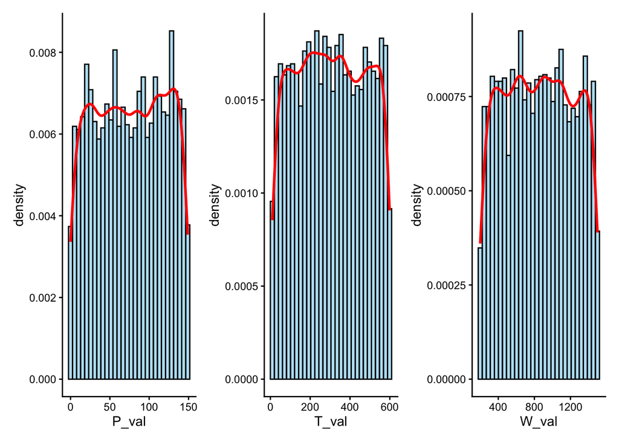

```r
# Combine histograms using patchwork
h1 <- ggplot(df_sum_cond_w, aes(x = P_val)) +
  geom_histogram(aes(y = after_stat(density)), bins = 30, fill = "skyblue", color = "black", alpha = 0.6) +
  geom_density(color = "red", size = 1) +
  labs(x = "P_val", y = "density") +
  theme_classic()
h2 <- ggplot(df_sum_cond_w, aes(x = T_val)) +
  geom_histogram(aes(y = after_stat(density)), bins = 30, fill = "skyblue", color = "black", alpha = 0.6) +
  geom_density(color = "red", size = 1) +
  labs(x = "T_val", y = "density") +
  theme_classic()

h3 <- ggplot(df_sum_cond_w, aes(x = W_val)) +
  geom_histogram(aes(y = after_stat(density)), bins = 30, fill = "skyblue", color = "black", alpha = 0.6) +
  geom_density(color = "red", size = 1) +
  labs(x = "W_val", y = "density") +
  theme_classic()

h1 + h2 + h3 + plot_layout(nrow = 1, guides = "collect")
```

# 3 2D CONTOUR METHODS

## Data Sparsity Check

```r
# Check completeness of design matrix (all combinations of P, T, W)
n_complete <- nrow(df_sum_cond_w)
n_unique_P <- length(unique(df_sum_cond_w$P_val))
n_unique_T <- length(unique(df_sum_cond_w$T_val))
n_unique_W <- length(unique(df_sum_cond_w$W_val))
n_possible <- n_unique_P * n_unique_T * n_unique_W

cat("=== Data Completeness Check ===\n")
```

```
## === Data Completeness Check ===
```

```r
cat("Actual observations:", n_complete, "\n")
```

```
## Actual observations: 5000
```

```r
cat("Unique P values:", n_unique_P, "\n")
```

```
## Unique P values: 150
```

```r
cat("Unique T values:", n_unique_T, "\n")
```

```
## Unique T values: 590
```

```r
cat("Unique W values:", n_unique_W, "\n")
```

```
## Unique W values: 1269
```

```r
cat("Possible combinations:", n_possible, "\n")
```

```
## Possible combinations: 112306500
```

```r
cat("Missing combinations:", n_possible - n_complete, "\n")
```

```
## Missing combinations: 112301500
```

```r
cat("Data completeness:", round(n_complete/n_possible * 100, 5), "%\n")
```

```
## Data completeness: 0.00445 %
```

## Approaches Comparison

The code are not evaluated. To run these chunks, change `eval=FALSE` to `eval=TRUE`.

### 1. ggplot stat_summary_2d (Quick Binning)

Bins data and shows density - works with sparse data.

```r
ggplot(df_sum_cond_w, aes(x = W_val, y = T_val, z = mean_RT_self)) +
  stat_summary_2d(bins = 20, na.rm = TRUE) +
  scale_fill_viridis_c(name = "RT") +
  labs(title = "stat_summary_2d: RT by W & T", x = "W", y = "T") +
  theme_minimal()
```

### 2. GAM Interpolation (Selected)

Fits GAM model and predicts on regular grid - smooth and statistically principled.

```r
gam_interp <- gam(mean_RT_self ~ te(W_val, T_val), data = df_sum_cond_w)

W_seq <- seq(min(df_sum_cond_w$W_val), max(df_sum_cond_w$W_val), length.out = 50)
T_seq <- seq(min(df_sum_cond_w$T_val), max(df_sum_cond_w$T_val), length.out = 50)
pred_grid <- expand.grid(W_val = W_seq, T_val = T_seq)
pred_grid$pred <- predict(gam_interp, newdata = pred_grid)

ggplot(pred_grid, aes(x = W_val, y = T_val, z = pred)) +
  geom_contour_filled(bins = 20) +
  scale_fill_viridis_d(name = "Predicted RT") +
  labs(title = "GAM Interpolation: RT by W & T", x = "W", y = "T") +
  theme_minimal()
```

### 3. ggplot + interp Package (Linear Interpolation)

Manual linear interpolation using interp package.

```r
pacman::p_load(interp)

interp_result <- with(df_sum_cond_w,
                      interp(x = W_val, y = T_val, z = mean_RT_self,
                             xo = seq(min(W_val), max(W_val), length = 100),
                             yo = seq(min(T_val), max(T_val), length = 100),
                             method = "linear",
                             duplicate = "mean"))

df_interp <- expand.grid(W = interp_result$x, T = interp_result$y)
df_interp$RT <- as.vector(interp_result$z)
df_interp <- df_interp %>% filter(!is.na(RT))

ggplot(df_interp, aes(x = W, y = T, z = RT)) +
  geom_contour_filled(bins = 20) +
  scale_fill_viridis_d(name = "RT") +
  labs(title = "Linear Interpolation (interp): RT by W & T", x = "W", y = "T") +
  theme_minimal()
```

### 4. plot_ly Contour (Time Consuming)

plot_ly’s built-in interpolation - reliable but slower.

```r
plot_ly(df_sum_cond_w, x = ~W_val, y = ~T_val, z = ~mean_RT_self, type = 'contour',
        colors = viridisLite::viridis(100), colorbar = list(title = "RT")) %>%
  layout(title = "plot_ly Contour: RT by W & T",
         xaxis = list(title = "W"), yaxis = list(title = "T"))
```

# 4. BOUNDARY SEPARATION (a)

## 4.1 Raw Data - 3D

```r
a_self_3d <- plotly::plot_ly(
  df_sum_cond_w,
  x = ~W_val, y = ~T_val, z = ~P_val,
  color = ~mean_a_self,
  colors = viridisLite::viridis(100),
  type = 'scatter3d', mode = 'markers',
  marker = list(size = 5)
) %>%
  plotly::layout(
    scene = list(
      xaxis = list(title = 'W'),
      yaxis = list(title = 'T'),
      zaxis = list(title = 'P')
    ),
    coloraxis = list(title = "a (self)", colorscale = "Viridis")
  )

a_stranger_3d <- plotly::plot_ly(
  df_sum_cond_w,
  x = ~W_val, y = ~T_val, z = ~P_val,
  color = ~mean_a_stranger,
  colors = viridisLite::viridis(100),
  type = 'scatter3d', mode = 'markers',
  marker = list(size = 5)
) %>%
  plotly::layout(
    scene = list(
      xaxis = list(title = 'W'),
      yaxis = list(title = 'T'),
      zaxis = list(title = 'P')
    ),
    coloraxis = list(title = "a (stranger)", colorscale = "Viridis")
  )

plotly::subplot(a_self_3d, a_stranger_3d, nrows = 1)
```

[interactive chart not shown]

## 4.2 Raw Data - 2D GAM (Self vs Stranger)

[figure not shown]

```r
a_self_gam <- make_gam_grid(df_sum_cond_w, "mean_a_self")
a_stranger_gam <- make_gam_grid(df_sum_cond_w, "mean_a_stranger")

a_pw_self <- plot_pair_contours(a_self_gam$grid, W_val, P_val, "P & W (Self)", "a_self")
a_tw_self <- plot_pair_contours(a_self_gam$grid, W_val, T_val, "T & W (Self)", "a_self")
a_tp_self <- plot_pair_contours(a_self_gam$grid, P_val, T_val, "T & P (Self)", "a_self")

a_pw_stranger <- plot_pair_contours(a_stranger_gam$grid, W_val, P_val, "P & W (Stranger)", "a_stranger")
a_tw_stranger <- plot_pair_contours(a_stranger_gam$grid, W_val, T_val, "T & W (Stranger)", "a_stranger")
a_tp_stranger <- plot_pair_contours(a_stranger_gam$grid, P_val, T_val, "T & P (Stranger)", "a_stranger")

(a_pw_self | a_tw_self | a_tp_self) /
  (a_pw_stranger | a_tw_stranger | a_tp_stranger)
```

## 4.3 Raw Differences (Self - Stranger)

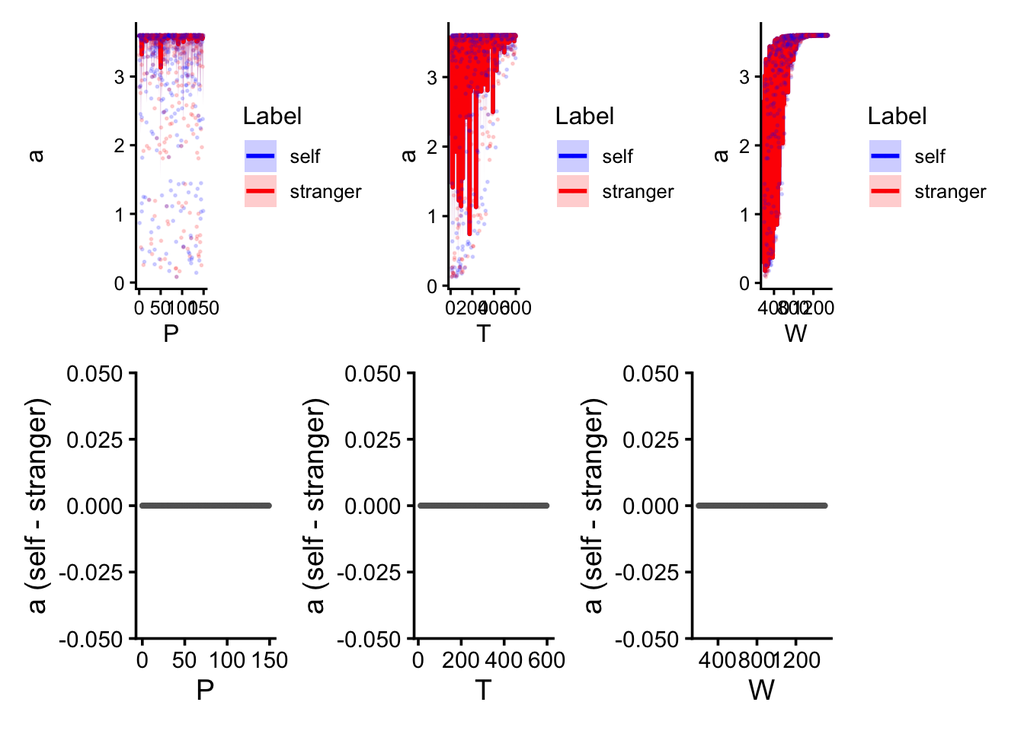

```r
# Top row: self + stranger profiles (need long format df_sum_cond)
a_profile_p <- plot_profile_comparison(df_sum_cond, P_val, mean_a, "P", "a")
a_profile_t <- plot_profile_comparison(df_sum_cond, T_val, mean_a, "T", "a")
a_profile_w <- plot_profile_comparison(df_sum_cond, W_val, mean_a, "W", "a")

# Bottom row: differences (using wide format df_sum_cond_w)
a_diff_data <- df_sum_cond_w %>%
  dplyr::select(P_val, T_val, W_val, a_diff)

a_diff_p <- plot_diff_summary(a_diff_data, P_val, a_diff, "P", "a (self - stranger)")
a_diff_t <- plot_diff_summary(a_diff_data, T_val, a_diff, "T", "a (self - stranger)")
a_diff_w <- plot_diff_summary(a_diff_data, W_val, a_diff, "W", "a (self - stranger)")

# 2-row layout: top = self/stranger profiles, bottom = differences
(a_profile_p | a_profile_t | a_profile_w) /
  (a_diff_p | a_diff_t | a_diff_w)
```

## 4.4 Cohen’s d - 3D

```r
plotly::plot_ly(
  df_sum_cond_w,
  x = ~P_val, y = ~T_val, z = ~W_val,
  color = ~cohen_d_a,
  colors = viridisLite::viridis(100),
  type = 'scatter3d', mode = 'markers',
  marker = list(size = 5)
) %>%
  plotly::layout(
    scene = list(
      xaxis = list(title = 'P'),
      yaxis = list(title = 'T'),
      zaxis = list(title = 'W')
    ),
    coloraxis = list(title = "Cohen's d (a)", colorscale = "Viridis")
  )
```

[interactive chart not shown]

## 4.5 Cohen’s d - 2D GAM

[figure not shown]

```r
a_d_gam <- make_gam_grid(df_sum_cond_w, "cohen_d_a")

a_d_pw <- plot_pair_contours(a_d_gam$grid, W_val, P_val, "P & W (Cohen's d a)", "cohen_d_a")
a_d_tw <- plot_pair_contours(a_d_gam$grid, W_val, T_val, "T & W (Cohen's d a)", "cohen_d_a")
a_d_tp <- plot_pair_contours(a_d_gam$grid, P_val, T_val, "T & P (Cohen's d a)", "cohen_d_a")

a_d_pw | a_d_tw | a_d_tp
```

# 5. DRIFT RATE (v)

## 5.1 Raw Data - 3D

```r
v_self_3d <- plotly::plot_ly(
  df_sum_cond_w,
  x = ~P_val, y = ~T_val, z = ~W_val,
  color = ~mean_v_self,
  colors = viridisLite::viridis(100),
  type = 'scatter3d', mode = 'markers',
  marker = list(size = 5)
) %>%
  plotly::layout(
    scene = list(
      xaxis = list(title = 'P'),
      yaxis = list(title = 'T'),
      zaxis = list(title = 'W')
    ),
    coloraxis = list(title = "v (self)", colorscale = "Viridis")
  )

v_stranger_3d <- plotly::plot_ly(
  df_sum_cond_w,
  x = ~P_val, y = ~T_val, z = ~W_val,
  color = ~mean_v_stranger,
  colors = viridisLite::viridis(100),
  type = 'scatter3d', mode = 'markers',
  marker = list(size = 5)
) %>%
  plotly::layout(
    scene = list(
      xaxis = list(title = 'P'),
      yaxis = list(title = 'T'),
      zaxis = list(title = 'W')
    ),
    coloraxis = list(title = "v (stranger)", colorscale = "Viridis")
  )

plotly::subplot(v_self_3d, v_stranger_3d, nrows = 1, shareX = FALSE, shareY = FALSE)
```

[interactive chart not shown]

## 5.2 Raw Data - 2D GAM (Self vs Stranger)

[figure not shown]

```r
v_self_gam <- make_gam_grid(df_sum_cond_w, "mean_v_self")
v_stranger_gam <- make_gam_grid(df_sum_cond_w, "mean_v_stranger")

v_pw_self <- plot_pair_contours(v_self_gam$grid, W_val, P_val, "P & W (Self)", "v_self")
v_tw_self <- plot_pair_contours(v_self_gam$grid, W_val, T_val, "T & W (Self)", "v_self")
v_tp_self <- plot_pair_contours(v_self_gam$grid, P_val, T_val, "T & P (Self)", "v_self")

v_pw_stranger <- plot_pair_contours(v_stranger_gam$grid, W_val, P_val, "P & W (Stranger)", "v_stranger")
v_tw_stranger <- plot_pair_contours(v_stranger_gam$grid, W_val, T_val, "T & W (Stranger)", "v_stranger")
v_tp_stranger <- plot_pair_contours(v_stranger_gam$grid, P_val, T_val, "T & P (Stranger)", "v_stranger")

(v_pw_self | v_tw_self | v_tp_self) /
  (v_pw_stranger | v_tw_stranger | v_tp_stranger)
```

## 5.3 Raw Differences (Self - Stranger)

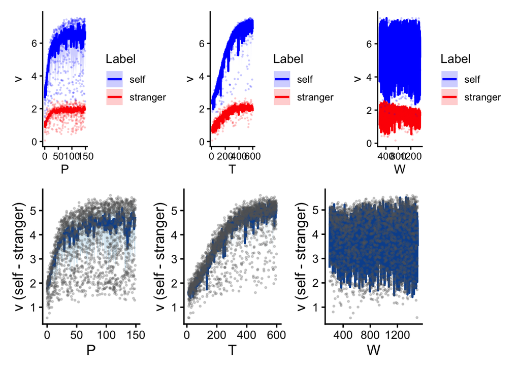

```r
# Top row: self + stranger profiles
v_profile_p <- plot_profile_comparison(df_sum_cond, P_val, mean_v, "P", "v")
v_profile_t <- plot_profile_comparison(df_sum_cond, T_val, mean_v, "T", "v")
v_profile_w <- plot_profile_comparison(df_sum_cond, W_val, mean_v, "W", "v")

# Bottom row: differences
v_diff_data <- df_sum_cond_w %>%
  dplyr::select(P_val, T_val, W_val, v_diff)

v_diff_p <- plot_diff_summary(v_diff_data, P_val, v_diff, "P", "v (self - stranger)")
v_diff_t <- plot_diff_summary(v_diff_data, T_val, v_diff, "T", "v (self - stranger)")
v_diff_w <- plot_diff_summary(v_diff_data, W_val, v_diff, "W", "v (self - stranger)")

(v_profile_p | v_profile_t | v_profile_w) /
  (v_diff_p | v_diff_t | v_diff_w)
```

## 5.4 Cohen’s d - 3D

```r
plotly::plot_ly(
  df_sum_cond_w,
  x = ~P_val, y = ~T_val, z = ~W_val,
  color = ~cohen_d_v,
  colors = viridisLite::viridis(100),
  type = 'scatter3d', mode = 'markers',
  marker = list(size = 5)
) %>%
  plotly::layout(
    scene = list(
      xaxis = list(title = 'P'),
      yaxis = list(title = 'T'),
      zaxis = list(title = 'W')
    ),
    coloraxis = list(title = "Cohen's d (v)", colorscale = "Viridis")
  )
```

[interactive chart not shown]

## 5.5 Cohen’s d - 2D GAM

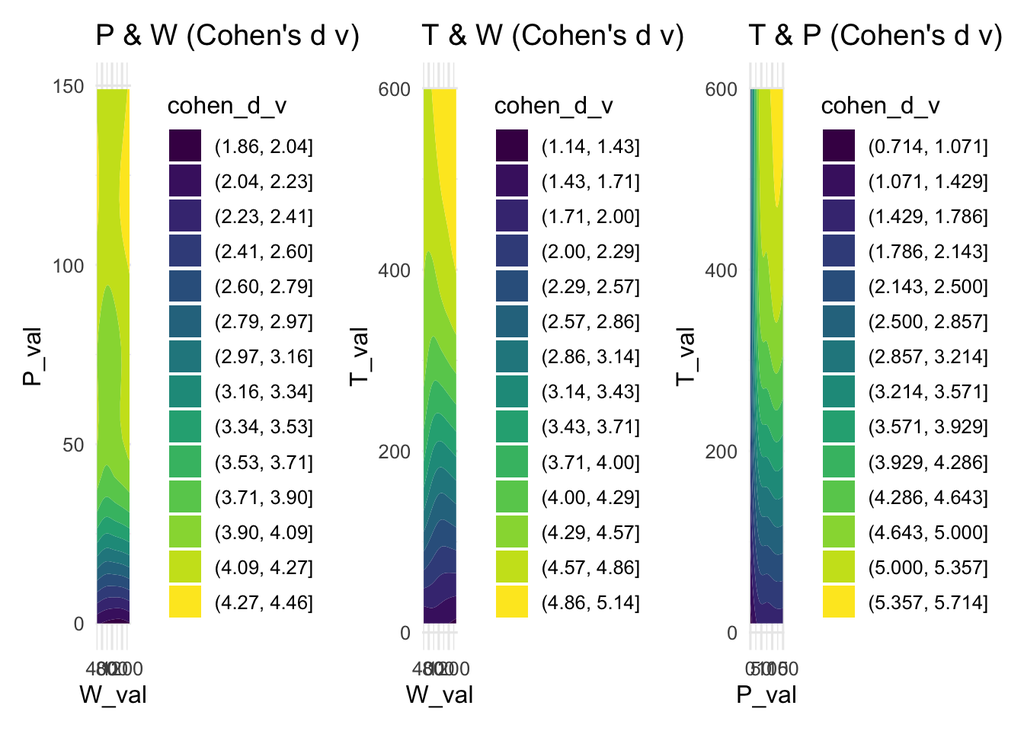

```r
v_d_gam <- make_gam_grid(df_sum_cond_w, "cohen_d_v")

v_d_pw <- plot_pair_contours(v_d_gam$grid, W_val, P_val, "P & W (Cohen's d v)", "cohen_d_v")
v_d_tw <- plot_pair_contours(v_d_gam$grid, W_val, T_val, "T & W (Cohen's d v)", "cohen_d_v")
v_d_tp <- plot_pair_contours(v_d_gam$grid, P_val, T_val, "T & P (Cohen's d v)", "cohen_d_v")

v_d_pw | v_d_tw | v_d_tp
```

# 6. REACTION TIME (RT)

## 6.1 Raw Data - 3D

```r
rt_self_3d <- plotly::plot_ly(
  df_sum_cond_w,
  x = ~P_val, y = ~T_val, z = ~W_val,
  color = ~mean_RT_self,
  colors = viridisLite::viridis(100),
  type = 'scatter3d', mode = 'markers',
  marker = list(size = 5)
) %>%
  plotly::layout(
    scene = list(
      xaxis = list(title = 'P'),
      yaxis = list(title = 'T'),
      zaxis = list(title = 'W')
    ),
    coloraxis = list(title = "RT (self)", colorscale = "Viridis")
  )

rt_stranger_3d <- plotly::plot_ly(
  df_sum_cond_w,
  x = ~P_val, y = ~T_val, z = ~W_val,
  color = ~mean_RT_stranger,
  colors = viridisLite::viridis(100),
  type = 'scatter3d', mode = 'markers',
  marker = list(size = 5)
) %>%
  plotly::layout(
    scene = list(
      xaxis = list(title = 'P'),
      yaxis = list(title = 'T'),
      zaxis = list(title = 'W')
    ),
    coloraxis = list(title = "RT (stranger)", colorscale = "Viridis")
  )

plotly::subplot(rt_self_3d, rt_stranger_3d, nrows = 1, shareX = FALSE, shareY = FALSE)
```

[interactive chart not shown]

## 6.2 Raw Data - 2D GAM (Self vs Stranger)

[figure not shown]

```r
rt_self_gam <- make_gam_grid(df_sum_cond_w, "mean_RT_self")
rt_stranger_gam <- make_gam_grid(df_sum_cond_w, "mean_RT_stranger")

rt_pw_self <- plot_pair_contours(rt_self_gam$grid, W_val, P_val, "P & W (Self)", "RT_self")
rt_tw_self <- plot_pair_contours(rt_self_gam$grid, W_val, T_val, "T & W (Self)", "RT_self")
rt_tp_self <- plot_pair_contours(rt_self_gam$grid, P_val, T_val, "T & P (Self)", "RT_self")

rt_pw_stranger <- plot_pair_contours(rt_stranger_gam$grid, W_val, P_val, "P & W (Stranger)", "RT_stranger")
rt_tw_stranger <- plot_pair_contours(rt_stranger_gam$grid, W_val, T_val, "T & W (Stranger)", "RT_stranger")
rt_tp_stranger <- plot_pair_contours(rt_stranger_gam$grid, P_val, T_val, "T & P (Stranger)", "RT_stranger")

(rt_pw_self | rt_tw_self | rt_tp_self) /
  (rt_pw_stranger | rt_tw_stranger | rt_tp_stranger)
```

## 6.3 Raw Differences (Self - Stranger)

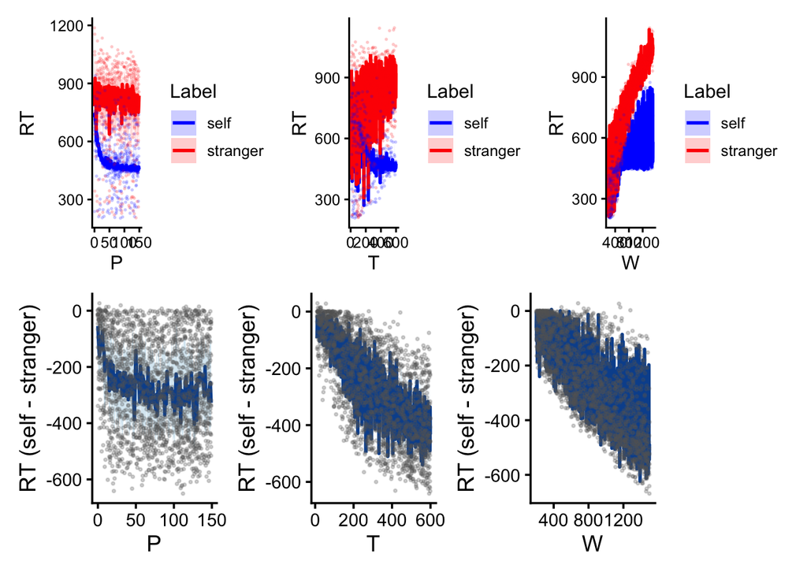

```r
# Top row: self + stranger profiles
rt_profile_p <- plot_profile_comparison(df_sum_cond, P_val, mean_RT, "P", "RT")
rt_profile_t <- plot_profile_comparison(df_sum_cond, T_val, mean_RT, "T", "RT")
rt_profile_w <- plot_profile_comparison(df_sum_cond, W_val, mean_RT, "W", "RT")

# Bottom row: differences
rt_diff_data <- df_sum_cond_w %>%
  dplyr::mutate(rt_diff = mean_RT_self - mean_RT_stranger) %>%
  dplyr::select(P_val, T_val, W_val, rt_diff)

rt_diff_p <- plot_diff_summary(rt_diff_data, P_val, rt_diff, "P", "RT (self - stranger)")
rt_diff_t <- plot_diff_summary(rt_diff_data, T_val, rt_diff, "T", "RT (self - stranger)")
rt_diff_w <- plot_diff_summary(rt_diff_data, W_val, rt_diff, "W", "RT (self - stranger)")

(rt_profile_p | rt_profile_t | rt_profile_w) /
  (rt_diff_p | rt_diff_t | rt_diff_w)
```

## 6.4 Cohen’s d - 3D

```r
plotly::plot_ly(
  df_sum_cond_w,
  x = ~P_val, y = ~T_val, z = ~W_val,
  color = ~cohen_d_RT,
  colors = viridisLite::viridis(100),
  type = 'scatter3d', mode = 'markers',
  marker = list(size = 5)
) %>%
  plotly::layout(
    scene = list(
      xaxis = list(title = 'P'),
      yaxis = list(title = 'T'),
      zaxis = list(title = 'W')
    ),
    coloraxis = list(title = "Cohen's d (RT)", colorscale = "Viridis")
  )
```

[interactive chart not shown]

## 6.5 Cohen’s d - 2D GAM

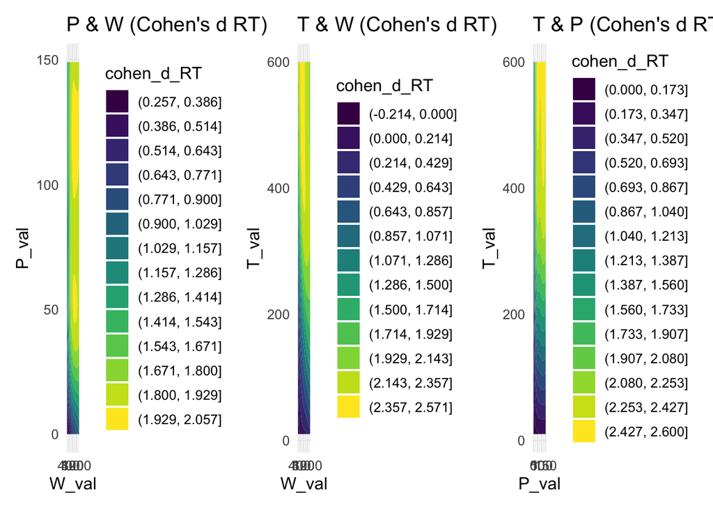

```r
rt_d_gam <- make_gam_grid(df_sum_cond_w, "cohen_d_RT")

rt_d_pw <- plot_pair_contours(rt_d_gam$grid, W_val, P_val, "P & W (Cohen's d RT)", "cohen_d_RT")
rt_d_tw <- plot_pair_contours(rt_d_gam$grid, W_val, T_val, "T & W (Cohen's d RT)", "cohen_d_RT")
rt_d_tp <- plot_pair_contours(rt_d_gam$grid, P_val, T_val, "T & P (Cohen's d RT)", "cohen_d_RT")

rt_d_pw | rt_d_tw | rt_d_tp
```

# 7. ACCURACY (ACC)

## 7.1 Raw Data - 3D

```r
acc_self_3d <- plotly::plot_ly(
  df_sum_cond_w,
  x = ~P_val, y = ~T_val, z = ~W_val,
  color = ~mean_ACC_self,
  colors = viridisLite::viridis(100),
  type = 'scatter3d', mode = 'markers',
  marker = list(size = 5)
) %>%
  plotly::layout(
    scene = list(
      xaxis = list(title = 'P'),
      yaxis = list(title = 'T'),
      zaxis = list(title = 'W')
    ),
    coloraxis = list(title = "ACC (self)", colorscale = "Viridis")
  )

acc_stranger_3d <- plotly::plot_ly(
  df_sum_cond_w,
  x = ~P_val, y = ~T_val, z = ~W_val,
  color = ~mean_ACC_stranger,
  colors = viridisLite::viridis(100),
  type = 'scatter3d', mode = 'markers',
  marker = list(size = 5)
) %>%
  plotly::layout(
    scene = list(
      xaxis = list(title = 'P'),
      yaxis = list(title = 'T'),
      zaxis = list(title = 'W')
    ),
    coloraxis = list(title = "ACC (stranger)", colorscale = "Viridis")
  )

plotly::subplot(acc_self_3d, acc_stranger_3d, nrows = 1, shareX = FALSE, shareY = FALSE)
```

[interactive chart not shown]

## 7.2 Raw Data - 2D GAM (Self vs Stranger)

[figure not shown]

```r
acc_self_gam <- make_gam_grid(df_sum_cond_w, "mean_ACC_self")
acc_stranger_gam <- make_gam_grid(df_sum_cond_w, "mean_ACC_stranger")

acc_pw_self <- plot_pair_contours(acc_self_gam$grid, W_val, P_val, "P & W (Self)", "ACC_self")
acc_tw_self <- plot_pair_contours(acc_self_gam$grid, W_val, T_val, "T & W (Self)", "ACC_self")
acc_tp_self <- plot_pair_contours(acc_self_gam$grid, P_val, T_val, "T & P (Self)", "ACC_self")

acc_pw_stranger <- plot_pair_contours(acc_stranger_gam$grid, W_val, P_val, "P & W (Stranger)", "ACC_stranger")
acc_tw_stranger <- plot_pair_contours(acc_stranger_gam$grid, W_val, T_val, "T & W (Stranger)", "ACC_stranger")
acc_tp_stranger <- plot_pair_contours(acc_stranger_gam$grid, P_val, T_val, "T & P (Stranger)", "ACC_stranger")

(acc_pw_self | acc_tw_self | acc_tp_self) /
  (acc_pw_stranger | acc_tw_stranger | acc_tp_stranger)
```

## 7.3 Raw Differences (Self - Stranger)

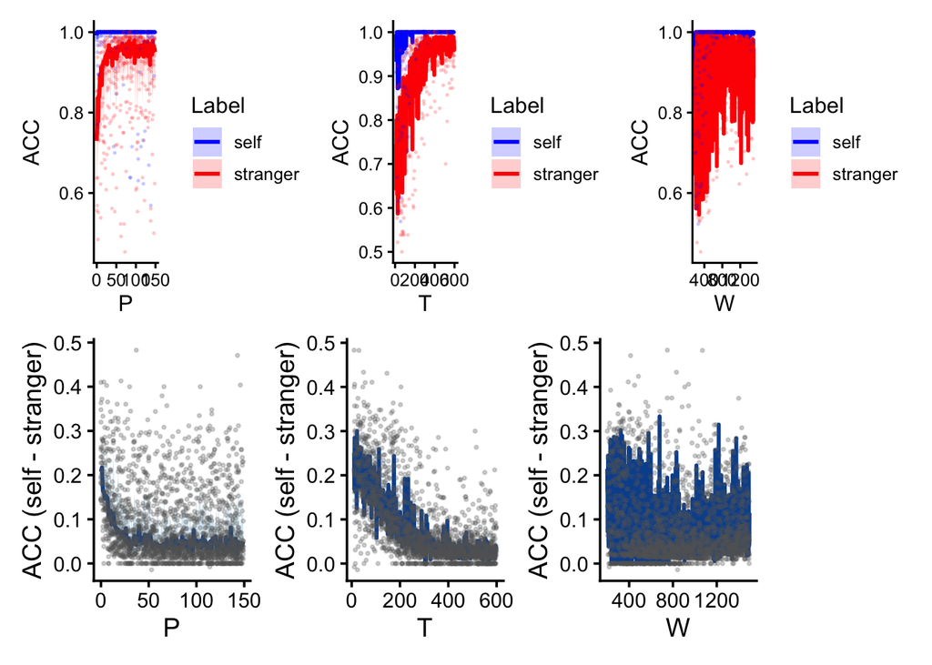

```r
# Top row: self + stranger profiles
acc_profile_p <- plot_profile_comparison(df_sum_cond, P_val, mean_ACC, "P", "ACC")
acc_profile_t <- plot_profile_comparison(df_sum_cond, T_val, mean_ACC, "T", "ACC")
acc_profile_w <- plot_profile_comparison(df_sum_cond, W_val, mean_ACC, "W", "ACC")

# Bottom row: differences
acc_diff_data <- df_sum_cond_w %>%
  dplyr::select(P_val, T_val, W_val, ACC_diff)

acc_diff_p <- plot_diff_summary(acc_diff_data, P_val, ACC_diff, "P", "ACC (self - stranger)")
acc_diff_t <- plot_diff_summary(acc_diff_data, T_val, ACC_diff, "T", "ACC (self - stranger)")
acc_diff_w <- plot_diff_summary(acc_diff_data, W_val, ACC_diff, "W", "ACC (self - stranger)")

(acc_profile_p | acc_profile_t | acc_profile_w) /
  (acc_diff_p | acc_diff_t | acc_diff_w)
```

## 7.4 Cohen’s d - 3D

```r
plotly::plot_ly(
  df_sum_cond_w,
  x = ~P_val, y = ~T_val, z = ~W_val,
  color = ~cohen_d_ACC,
  colors = viridisLite::viridis(100),
  type = 'scatter3d', mode = 'markers',
  marker = list(size = 5)
) %>%
  plotly::layout(
    scene = list(
      xaxis = list(title = 'P'),
      yaxis = list(title = 'T'),
      zaxis = list(title = 'W')
    ),
    coloraxis = list(title = "Cohen's d (ACC)", colorscale = "Viridis")
  )
```

[interactive chart not shown]

## 7.5 Cohen’s d - 2D GAM

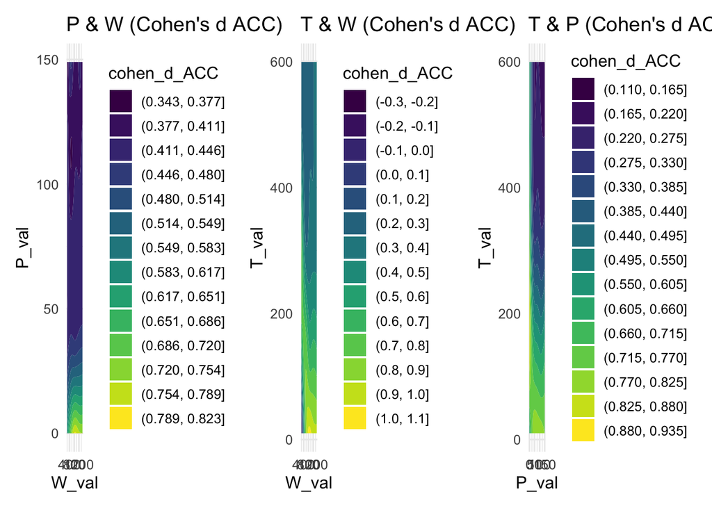

```r
acc_d_gam <- make_gam_grid(df_sum_cond_w, "cohen_d_ACC")

acc_d_pw <- plot_pair_contours(acc_d_gam$grid, W_val, P_val, "P & W (Cohen's d ACC)", "cohen_d_ACC")
acc_d_tw <- plot_pair_contours(acc_d_gam$grid, W_val, T_val, "T & W (Cohen's d ACC)", "cohen_d_ACC")
acc_d_tp <- plot_pair_contours(acc_d_gam$grid, P_val, T_val, "T & P (Cohen's d ACC)", "cohen_d_ACC")

acc_d_pw | acc_d_tw | acc_d_tp
```